# VisualizeNetworks

David Smith

2022-10-17

$\uparrow$ Library || Landscapes

# `dev`

Functions to visualize networks.

### Setup

```r
xy = cbind(c(-2, 0, 2, 0), c(0,2,0,-2))
M = matrix(0,4,4)
M[1,2] = 2
M[1,3] = 1/2
M[1,4] = 2
M[2,1] = 1/2
M[3,1] = 2
M[4,1] = 1/2

M[2,3] = 1/3
M[2,4] = 3
M[3,2] = 3
M[4,2] = 1/3

M[3,4] = 4
M[4,3] = 1/4
```

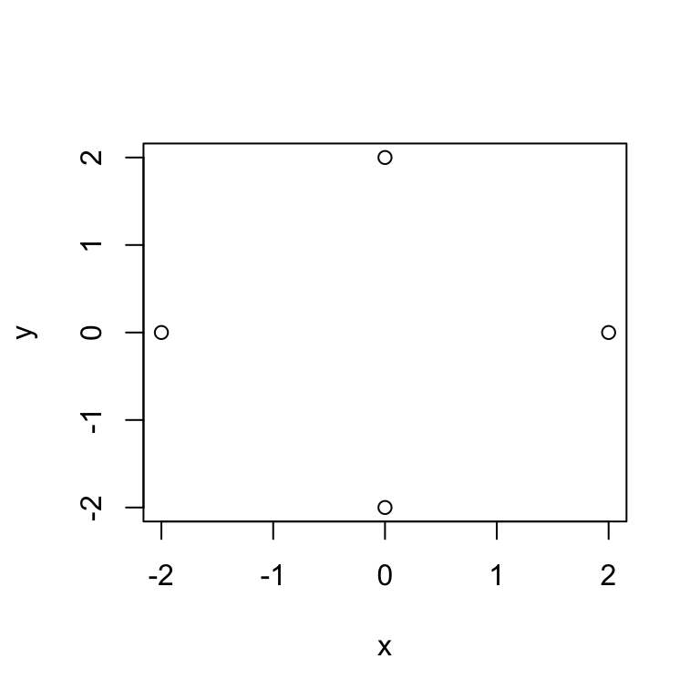

```r
plot(xy, xlab = "x", ylab = "y")
```

## Arrows

### arrowsX2Y

This adds arrows from one point set to another, from $\left\{x \right\} \rightarrow \left\{y\right\}$.

The arrows can be bent.

```r
arrowsX2Y = function(xy1, xy2, M, mnwd=0.05, bbend=1, endd=0.75, adj=2, clr="red"){
  n1 = dim(xy1)[1]
  n2 = dim(xy2)[1]
  adj = adj/max(M)
  for(i in 1:n1)
    for (j in c(1:n2))
      if (M[j,i] > mnwd*max(M)){
        fac = M[j,i]*adj
        curvedarrow(xy1[i,], xy2[j,],
                  segment=c(0.1, endd), lwd=fac, curve = 0.01*bbend,
                  arr.pos=endd, arr.length=0.15*fac, arr.width=0.1*fac,
                  arr.type="curved", arr.col = clr, lcol = clr)
      }
}
```

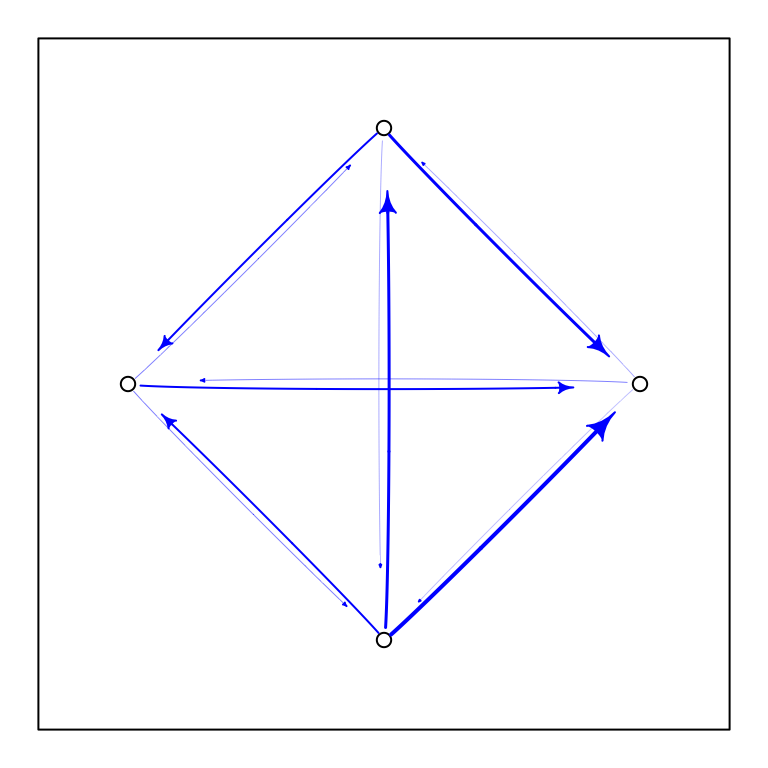

```r
par(mar = c(1,1,1,1))
plot(xy, xlim = c(-2.5,2.5), ylim = c(-2.5,2.5), xaxt = "n", yaxt = "n")
arrowsX2Y(xy, xy, M, clr="blue")
```

### arrowsX2X

This plots arrows from one point set to itself.

```r
arrowsX2X = function(xy, M, mnwd=0.05, bbend=1, adj=2, endd=0.75, clr = "red" ){
  n = dim(xy)[1]
  diag(M) <- 0
  adj = adj/max(M)
  for(i in 1:n)
    for(j in c(1:n)[-i])
      if (M[j,i]> mnwd*max(M)){
        fac = M[j,i]*adj
        curvedarrow(xy[i,], xy[j,],
                  segment=c(0.1, endd), lwd=fac, curve = 0.01*bbend,
                  arr.pos=endd, arr.length=0.15*fac, arr.width=0.1*fac,
                  arr.type="curved", arr.col = clr, lcol = clr)
  }
}
```

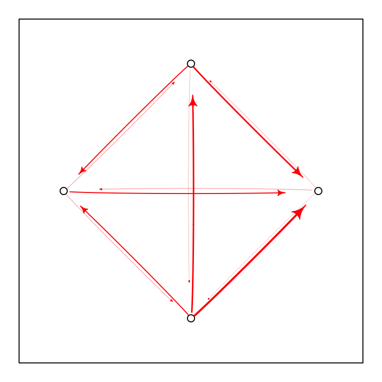

```r
par(mar = c(1,1,1,1))
plot(xy, xlim = c(-2.5,2.5), ylim = c(-2.5,2.5), xaxt = "n", yaxt = "n")
arrowsX2X(xy, M)
```

### avgX2X

One way to visualize average connectivity is to connect points with segments weighted by the average flow. Given a matrix, $D$, the symmetric flows are described by $(D + D^T)/2,$ where $D^T$ is the transpose of $D$.

We visualize this with `avgX2X`

```r
avgX2X = function(xy, M, mnwd=0.05, bbend=1, adj=2, clr = grey(0.7) ){
  n = dim(xy)[1]
  diag(M)<-0
  M <- (M + t(M))/2
  scl <- max(M)
  adj = adj/max(M)
  for(i in 1:n)
    for(j in c(1:n)[-i])
       if(M[j,i]> mnwd*scl){
          fac = M[i,j]*adj
          segments(xy[i,1], xy[i,2], xy[j,1], xy[j,2], col=clr, lwd=fac)
  }
}
```

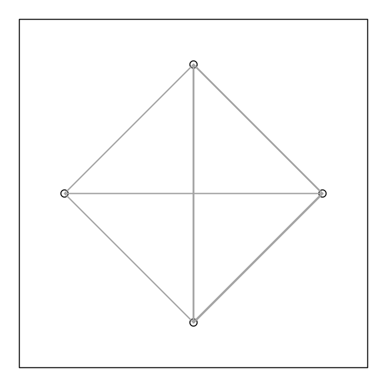

```r
par(mar = c(1,1,1,1))
plot(xy, xlim = c(-2.5,2.5), ylim = c(-2.5,2.5), xaxt = "n", yaxt = "n")
avgX2X(xy, M)
```

### flowX2X and symX2X

To visualize flows on a directed graph, we decompose these graphs into two new graphs. A matrix $D$ can be expressed as the sum of a symmetric matrix $D_s$ and an matrix with only pure asymmetric flows $D_f$. The symmetric matrix is the minimum of the matrix and its transpose, $D^T$:

$$\begin{equation}
D_s = \min(D, D^T)
\end{equation}$$

and the residual flow is:

$$\begin{equation}
D_f = D-D_s
\end{equation}$$

Note that if $i\neq d_{ij}$, then for all $d_{i,j}, d_{j,i} \in D_f =0$, either $d_{i,j} =0$ or $d_{j,i}=0$.

We visualize $D_f$ with the function `flowX2X` and we plot $D_s$ with the function `symX2X`.

```r
decompM=function(M){
  diagonal = diag(M)
  diag(M) <- 0
  connect = pmin(M, t(M))
  flow = t(M-connect)
  list(connect=connect, flow=flow, diagonal=diagonal)
}
```

```r
flowX2X = function(xy, M, mnwd=0.05,  bbend=1, adj=2, endd=0.75, clr = "red" ){
  n = dim(xy)[1]
  diag(M)<-0
  scl <- max(M - t(M))
  adj = adj/scl

  for(i in 1:n)
    for(j in c(1:n)[-i])
      if(M[j,i] > M[i,j])
         if(M[j,i]> mnwd*scl){
           fac = (M[j,i]-M[i,j])*adj
           curvedarrow(xy[i,], xy[j,],
                  segment=c(0.1, endd), lwd=fac, curve = 0.01*bbend,
                  arr.pos=endd, arr.length=0.15*fac, arr.width=0.1*fac,
                  arr.type="curved", arr.col = clr, lcol = clr)
  }
}
```

```r
symX2X = function(xy, M, mnwd=0.05, bbend=1, adj=2, clr = grey(0.7) ){
  n = dim(xy)[1]
  diag(M)<-0
  M <- pmin(M, t(M))
  scl <- max(M)
  adj = adj/max(M)
  for(i in 1:n)
    for(j in c(1:n)[-i])
       if(M[j,i]> mnwd*scl){
          fac = M[i,j]*adj
          segments(xy[i,1], xy[i,2], xy[j,1], xy[j,2], col=clr, lwd=fac)
  }
}
```

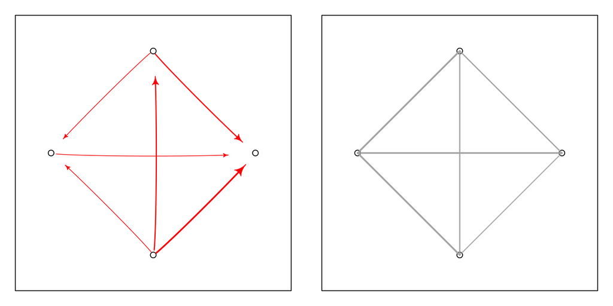

```r
par(mar = c(1,1,1,1), mfrow = c(1,2))
plot(xy, xlim = c(-2.5,2.5), ylim = c(-2.5,2.5), xaxt = "n", yaxt = "n")
flowX2X(xy, M, bbend=1.5)
plot(xy, xlim = c(-2.5,2.5), ylim = c(-2.5,2.5), xaxt = "n", yaxt = "n")
symX2X(xy, M, bbend=0)
```

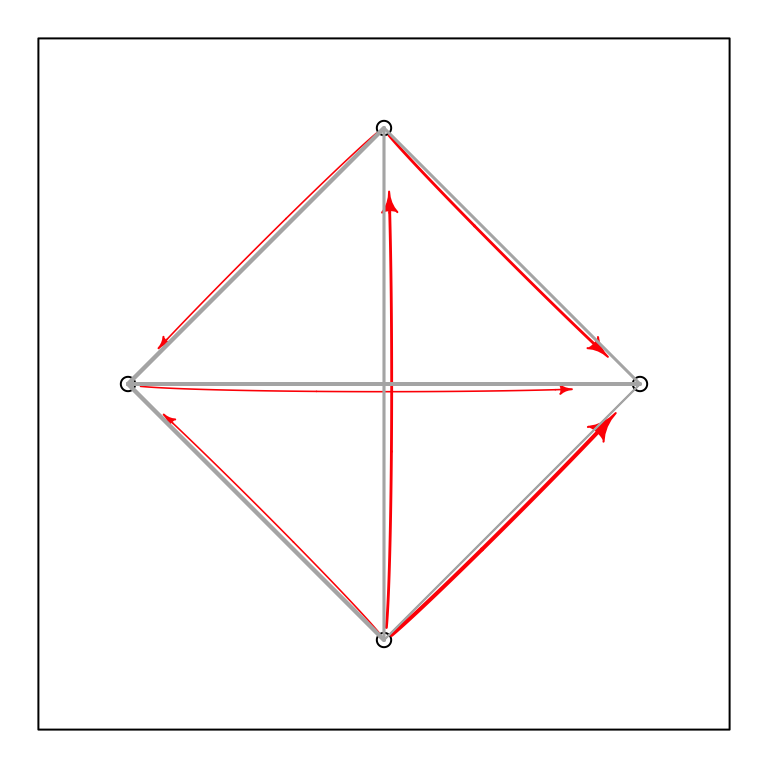

```r
par(mar = c(1,1,1,1), mfrow = c(1,1))
plot(xy, xlim = c(-2.5,2.5), ylim = c(-2.5,2.5), xaxt = "n", yaxt = "n")
flowX2X(xy, M, bbend=1.5)
symX2X(xy, M, bbend=0)
```